# Direction of Trade and Financial Development

# Abstract

The purpose of this exploratory analysis is to determine which countries have experienced the greatest trade growth with the United States since 1980, as well as to determine if the International Monetary Fund’s Financial Development Index can be used as a method of determining trade growth in imports and/or exports.

# Set-up Procedures

The following packages were installed in the R session used throughout this report and will be necessary for replication. *tidyverse* may be substituted for smaller individual packages, but the size of the files and package size or not restrictive on most modern systems.

```r
library(tidyverse)
library(dplyr)
library(reshape2)
library(Hmisc)
```

# Datasets

All datasets have been taken from the International Monetary Fund’s (IMF) open data query windows accessible in their online portal. These includes three datasets as detailed below. Each dataset underwent unique transformations which will be explained in detail and include the R code used.

## Direction of Trade Dataset

The first and most crucial dataset is that of Direction of Trade (DOT). These figures are collected or estimated for all included nations by IMF data collectors and are measured for both imports and exports. The standard currency is United States Dollars (USD) and as such all calculations will be using this currency.

There are infact two sets of data which must be downloaded independently into an .xlsx format. These files were downloaded and slightly modified in Microsoft Excel to remove extraneous headers and rename columns to their full names for clarity. After these simple data cleansing steps, the .xlsx files were changed to .csv and imported into R.

Because the datasets was set up to appear as a PivotTable, it was necessary to *melt* the frames into a columnar format for later changes to be applied. Additionally, because the datasets are much the same except for the the fact that one is import and the other is export, it made sense to combine the tables and rename the columns for Import and Export. Take note that the variable column should state Year, but the rename function was not able to capture the correct column for reassignment.

```r
DOT_imports <- read.csv("C:/Users/jewel/Downloads/US_imports.csv", header = TRUE, sep = ",")
DOT_imports <- melt(data =  DOT_imports, id.vars = "Area", value.name = "Import")

DOT_exports <- read.csv("C:/Users/jewel/Downloads/US_exports.csv", header = TRUE, sep = ",")
DOT_exports <- melt(data =  DOT_exports, id.vars = "Area", value.name = "Export")

DOT_merge <- merge(DOT_imports, DOT_exports, by.x = c("Area", "variable"), by.y = c("Area", "variable"), all.x = TRUE)
```

## Consumer Price Index Dataset

The Consumer Price Index is an index calculated using the value of a single basket of goods over time. It is regularly used to measure inflation, and as such will be used to remove inflationary effects on trade statistics to show the true growth in the figures over time. The CPI was also in a Pivot styel table and was melted to correct it. This data was then added to the combined dataset for later calculations.

```r
CPI <- read.csv("C:/Users/jewel/Downloads/Consumer_Price_Index_CPI.csv", header = TRUE, sep = ",")
CPI <- melt(data = CPI, id.vars = "Area", value.name = "CPI")

DOT_CPI_merge <- merge(DOT_merge, CPI, by.x = "variable", by.y = "variable", all.x = TRUE)
DOT_CPI_merge$Area.y <- NULL
```

## Financial Development Index

The IMF Financial Development Index (FDI) is designed as a measure of several economic indicators (such as efficiency, accessibility, etc.) that are designed to provide a high-level view of the economic soundness of a given country and time period. This index is a weighted average of several other indexes, and as such could be subdivided into further study, but that is not the focus of this study. Like the other datasets before it, the FDI data was extracted to Excel, slightly modified, converted to a .csv, and then uploaded to the R session.

Once uploaded, the data was again melted and combined to create a large single dataset from which to work from.

```r
FDI <- read.csv("C:/Users/jewel/Downloads/Financial_Development_FD.csv", header = TRUE, sep = ",")
FDI <- melt(data = FDI, id.vars = "Area", value.name = "FDI")

D_C_F_merge <- merge(DOT_CPI_merge, FDI, by.x = c("Area.x", "variable"), by.y = c("Area", "variable"), all.x = TRUE)
D_C_F_merge$Area.y <- NULL
```

# Analysis

## Inflation Correction

Of primary concern were the inflation adjusted value of the Imports and Exports. Because the combined dataframe now includes all three values, we can first mutate the columns to create new calculated values.

```r
D_C_F_merge <- D_C_F_merge %>% mutate(Import_adjusted = Import / CPI) %>% mutate(Export_adjusted = Export / CPI)
D_C_F_merge <- D_C_F_merge %>%
  mutate(Year = as.integer(substring(variable, 2, 5)))
D_C_F_merge$variable <- NULL

head(D_C_F_merge)
```

```
##                 Area.x Import Export      CPI FDI Import_adjusted
## 1 Afghanistan, I.R. of   13.6    6.5 41.69810  NA       0.3261540
## 2 Afghanistan, I.R. of   12.4   10.0 44.25479  NA       0.2801957
## 3 Afghanistan, I.R. of    8.8    5.1 45.67644  NA       0.1926595
## 4 Afghanistan, I.R. of   13.9    7.4 47.64078  NA       0.2917669
## 5 Afghanistan, I.R. of    7.1    3.5 49.32995  NA       0.1439288
## 6 Afghanistan, I.R. of    5.4    7.6 50.26625  NA       0.1074279
##   Export_adjusted Year
## 1      0.15588240 1981
## 2      0.22596425 1982
## 3      0.11165492 1983
## 4      0.15532912 1984
## 5      0.07095081 1985
## 6      0.15119487 1986
```

## Growth by country

One of the first questions that came to mind was which country has experienced the greatest growth over the total timeframe and to see the trend of all areas. To do so, a graph was employed to show large trends and open new avenues for dissection.

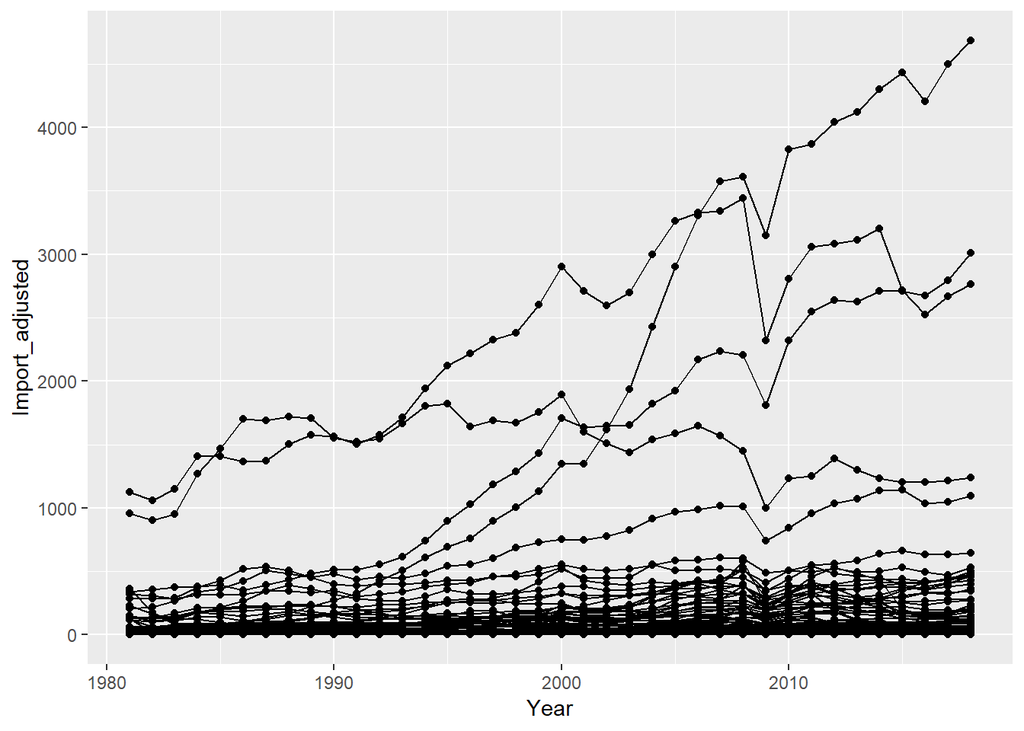

```r
ggplot(data = D_C_F_merge, aes(x = Year, y = Import_adjusted, group = Area.x)) +
  geom_line() +
  geom_point()
```

It appears that the Import_adjusted variable does indeed have an upward trend. One question that arises though is how strong are the correlations by each nation? In order to do so the D_C_F_merge dataset was converted to a list column to to calculate the total change experienced and show the largest gaining nations in Import_adjusted and Export_adjusted.

The first step was to create the list column nested object in order to apply the linear regression on all Area.x values (Countries).

```r
By_country <- D_C_F_merge %>%
  group_by(Area.x) %>%
  nest()
```

With this nested frame we can then create a function that defines a linear regression and apply it to all Area.x values in the nested frame. Per the recommendation of the #R for Data Science# book by Hadley Wickham the linear models have also been stored in the nested object as a new data type column.

```r
Import_reg <- function(df) {
  lm(Import_adjusted ~ Year, data = df)
}

Imp_by_country <- By_country %>%
  mutate(models = map(data, Import_reg))

Imp_by_country
```

```
## # A tibble: 220 x 3
##    Area.x               data              models
##    <fct>                <list>            <list>
##  1 Afghanistan, I.R. of <tibble [38 x 7]> <S3: lm>
##  2 Africa n.s.          <tibble [38 x 7]> <S3: lm>
##  3 Albania              <tibble [38 x 7]> <S3: lm>
##  4 Algeria              <tibble [38 x 7]> <S3: lm>
##  5 Angola               <tibble [38 x 7]> <S3: lm>
##  6 Anguilla             <tibble [38 x 7]> <S3: lm>
##  7 Antigua and Barbuda  <tibble [38 x 7]> <S3: lm>
##  8 Argentina            <tibble [38 x 7]> <S3: lm>
##  9 Armenia              <tibble [38 x 7]> <S3: lm>
## 10 Aruba                <tibble [38 x 7]> <S3: lm>
## # ... with 210 more rows
```

Once again, under the direction of #R for Data Science#, the models were unnested in order to analyze some of the metadaat of each model on a by country basis.

```r
Glance <- Imp_by_country %>%
  mutate(Glance = map(models, broom::glance)) %>%
  unnest(Glance, .drop = TRUE)

Glance %>%
  arrange(desc(r.squared))
```

```
## # A tibble: 220 x 12
##    Area.x     r.squared adj.r.squared     sigma statistic    p.value    df
##    <fct>          <dbl>         <dbl>     <dbl>     <dbl>      <dbl> <int>
##  1 Sint Maar~     1           NaN     NaN           NaN   NaN            2
##  2 Montserrat     0.991         0.982   7.05e-4     109.    6.08e- 2     2
##  3 Anguilla       0.987         0.974   3.07e-3      76.1   7.27e- 2     2
##  4 Bangladesh     0.979         0.978   2.57e+0    1645.    1.19e-31     2
##  5 Curacao        0.968         0.936   4.54e-2      30.1   1.15e- 1     2
##  6 Vatican        0.962         0.924   9.90e-4      25.3   1.25e- 1     2
##  7 San Marino     0.962         0.923   1.35e-2      25.1   1.25e- 1     2
##  8 Mexico         0.961         0.960   1.81e+2     896.    4.94e-27     2
##  9 Czech Rep~     0.960         0.958   2.67e+0     569.    3.19e-18     2
## 10 China,P.R~     0.927         0.925   4.62e+2     458.    4.67e-22     2
## # ... with 210 more rows, and 5 more variables: logLik <dbl>, AIC <dbl>,
## #   BIC <dbl>, deviance <dbl>, df.residual <int>
```

As we can see, there are several countries where the model describes the growth quite well, which begs the question: which countries have the strongest growth? To look more closely at this, we can use #broom::tidy# to see the model coeffecients.

```r
Tidy_glance <- Imp_by_country %>%
  mutate(Tidy_glance = map(models, broom::tidy)) %>%
  unnest(Tidy_glance, .drop = TRUE)

Tidy_glance %>%
  arrange(desc(estimate))
```

```
## # A tibble: 440 x 6
##    Area.x                term        estimate std.error statistic  p.value
##    <fct>                 <chr>          <dbl>     <dbl>     <dbl>    <dbl>
##  1 Japan                 (Intercept)    9567.    7724.      1.24  2.23e- 1
##  2 China,P.R.: Hong Kong (Intercept)    8173.     682.     12.0   4.02e-14
##  3 Netherlands Antilles  (Intercept)    1687.     388.      4.35  1.18e- 4
##  4 Bahamas, The          (Intercept)     873.     194.      4.49  7.03e- 5
##  5 Iran, I.R. of         (Intercept)     749.     202.      3.70  7.78e- 4
##  6 Libya                 (Intercept)     560.     912.      0.614 5.46e- 1
##  7 Cameroon              (Intercept)     495.     106.      4.69  3.91e- 5
##  8 Congo, Dem. Rep. of   (Intercept)     414.      48.6     8.52  3.72e-10
##  9 China,P.R.: Macao     (Intercept)     385.     162.      2.38  2.29e- 2
## 10 Jamaica               (Intercept)     361.      67.1     5.38  4.65e- 6
## # ... with 430 more rows
```

For the time being, we can assume that there is a noticeable level of growth in some nations, and that some nations have a clearly linear growth.

## FDI Effects

The first question of interest in regards to Financial Development Index is whether there is an increase in FDI statistics over time. As this index in does not need to be adjusted to match as single year (as opposed to the inflation correction of the Import and Export figures) that step will be bypassed and the FDI shown in a graph per Country.

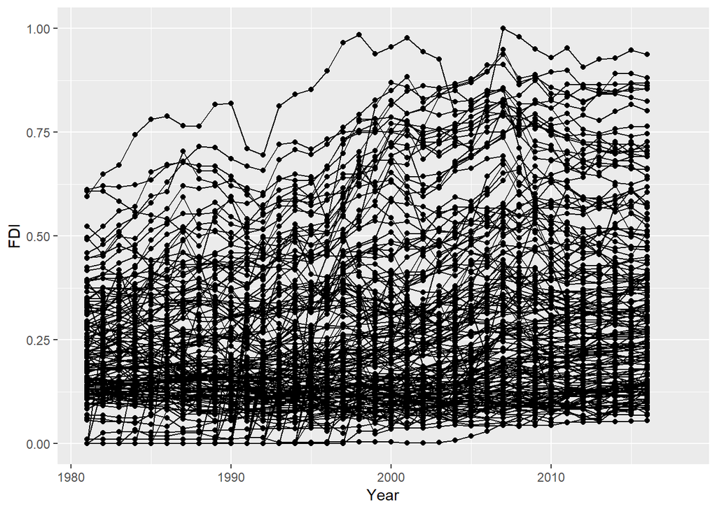

```r
ggplot(D_C_F_merge, aes(x = Year, y = FDI, group = Area.x)) +
  geom_line() +
  geom_point()
```

```r
Pearson_test <- cor.test(D_C_F_merge$Import, D_C_F_merge$FDI, method = "pearson")

Pearson_test
```

```
##
##  Pearson's product-moment correlation
##
## data:  D_C_F_merge$Import and D_C_F_merge$FDI
## t = 31.564, df = 5403, p-value < 2.2e-16
## alternative hypothesis: true correlation is not equal to 0
## 95 percent confidence interval:
##  0.3718233 0.4168478
## sample estimates:
##       cor
## 0.3945724
```

Further study on this topic would be useful to determine how the FDI effects each nation individually. This way a clearer correlation sould be seen and perhaps stronger models could be designed to predict future growth from this dataset.

# Conclusions

As an investor or economist, it should be evident that investment into the fastest growing importing/exporting countries, or those that are substantially increasing their FDI scores would likely be highly lucrative investments, and perhaps a good avenue for future research to see which of hte FDI indexes are the most impactful in such a scenario.